# Milestone Report - Exploratory Data Analysis

James Baxter

February 18, 2017

## Introduction

This is the milestone report for the Coursera Capstone project. The Capstone objective is to build an application that uses a predictive model to provide a list of possible ‘next’ words based on a word that was entered. This could be useful for applications such as texting and email mobile apps.

This project utilizes Natural Language Processing (NLP) concepts such as n-gram. N-gram is a contiguous sequence of n items from a given sequence of text or speech. The predictive model relies extensively on the concept of n-gram as the word that we are trying to predict relies on the word(s) that precede(s) it.

We will be using this data later on in the course to build the word prediction algorithm. Based on the results of this exploration we will also plan the design of our prediction algorithm and a hosting Shiny app.

This report includes functional in-line R code so that the results can be duplicated. The sections which follow outline the steps required to import, process, and visualize the data.

## Data Processing

### Load the data

Load the relevant packages and set up global settings:

```r
library(knitr)    # install.packages("knitr")
library(dplyr)    # install.packages("dplyr")
library(stringi)  # install.packages("stringi")
library(tm)       # install.packages("tm")
                  # RWeka requires Java Runtime: https://www.java.com/en/download/manual.jsp
library(RWeka)    # install.packages("RWeka")
library(ggplot2)  # install.packages("ggplot2")
library(wordcloud)# install.packages("wordcloud")
library(ngram)    # install.packages("ngram")

sampleSize <- 1000# adjust per memory capability

opts_chunk$set(echo = T, cache= TRUE)
```

Download the data from the provided URL:

```r
if (!file.exists("Coursera-SwiftKey.zip")){
        download.file("https://d396qusza40orc.cloudfront.net/dsscapstone/dataset/Coursera-SwiftKey.zip",
                      "Coursera-SwiftKey.zip")
  unzip("Coursera-SwiftKey.zip")
}
```

The data sets consist of text from Blogs, News, and Twitter feeds. The data sets are provided in 4 languages: German, English (US), Finnish and Russian. For this project, we will focus on only the English data set.

Load the data files into R, extract 1,000 samples from each, and create some summary statistics:

```r
if (!(file.exists("./AllDataSamples.txt") & (file.exists("./fileSummary.RDS")))) {

  ### Read data files

  blogs <- readLines("./final/en_US/en_US.blogs.txt", encoding = "UTF-8", skipNul=TRUE)
  news <- readLines("./final/en_US/en_US.news.txt", encoding = "UTF-8", skipNul=TRUE)
  twitter <- readLines("./final/en_US/en_US.twitter.txt", encoding = "UTF-8", skipNul=TRUE)

  ### Extract a data sample from each file

  sampleTwitter <- twitter[sample(1:length(twitter),sampleSize)]
  sampleNews <- news[sample(1:length(news),sampleSize)]
  sampleBlogs <- blogs[sample(1:length(blogs),sampleSize)]
  dataSample <- c(sampleTwitter,sampleNews,sampleBlogs)

  ### Save combined samples to text files

  writeLines(sampleTwitter, "./TwitterSamples.txt")
  writeLines(sampleNews, "./NewsSamples.txt")
  writeLines(sampleBlogs, "./BlogsSamples.txt")
  writeLines(dataSample, "./AllDataSamples.txt")

  ### Gather Data Set Statistics

  # Get file sizes
  blogs.size <- file.info("final/en_US/en_US.blogs.txt")$size / 1024 ^ 2
  news.size <- file.info("final/en_US/en_US.news.txt")$size / 1024 ^ 2
  twitter.size <- file.info("final/en_US/en_US.twitter.txt")$size / 1024 ^ 2
  sample.size <- file.info("./DataSample.txt")$size / 1024 ^ 2

  # Get the number of words in each file
  # stri_count_words {stringi} - count the number of text boundaries
  blogs.words <- stri_count_words(blogs)
  news.words <- stri_count_words(news)
  twitter.words <- stri_count_words(twitter)
  sample.words <- stri_count_words(dataSample)

  # Create a summary of the data sets
  fileSummary <- data.frame(source = c("blogs", "news", "twitter","dataSample"),
                    file.size.MB = c(blogs.size, news.size, twitter.size,sample.size),
                    num.lines = c(length(blogs), length(news), length(twitter), length(dataSample)),
                    num.words = c(sum(blogs.words), sum(news.words), sum(twitter.words), sum(sample.words)),
                    mean.words = c(mean(blogs.words), mean(news.words), mean(twitter.words), mean(sample.words)))

  colnames(fileSummary) <- c("File Name", "File Size (MB)", "Line Count", "Word Count", "Avg Words/Line")

  saveRDS(fileSummary, file = "./fileSummary.RDS")

  ## memory cleanup
  rm(blogs)
  rm(blogs.size)
  rm(blogs.words)
  rm(fileSummary)
  rm(news)
  rm(news.size)
  rm(news.words)
  rm(sample.size)
  rm(sample.words)
  rm(sampleBlogs)
  rm(sampleNews)
  rm(sampleTwitter)
  rm(twitter)
  rm(twitter.size)
  rm(twitter.words)
}

con <- file("./AllDataSamples.txt")
dataSample <- readLines(con)
close(con)
rm(con)

fileSummaryDF <- readRDS("./fileSummary.RDS")
```

### Data Cleaning

Now we will create a ‘corpus’ and ‘clean’ the data sample before performing any exploratory analysis to avoid counting words twice because of capitalization, punctuation, etc., so we will remove URLs, special characters, punctuations, numbers, excess whitespace, stopwords, and change the text to lower case.

A common definition of a ‘corpus’ is “a collection of written texts, especially the entire works of a particular author or a body of writing on a particular subject.” The corpus for this predictive modeling exercise is the combination of the sampled text lines from the blog, news, and twitter data sets:

```r
### Read data files
if (!file.exists("./cleanedCorpus.RDS")) {

  # Create a 'corpus' and clean up the data
  # A corpus creates a seperate document from each line in the source text + it's metadata
  # VCorpus {tm} - create volatile corpora
  # VectorSource {tm} - create a vector source which interprets each element of the vector as a document
  corpus <- VCorpus(VectorSource(dataSample))
  # content_transformer {tm} - create content transformers - functions which modify the content of an R object
  toSpace <- content_transformer(function(x, pattern) gsub(pattern, " ", x))
  # tm_map {tm} - transformation on corpora - interface to apply functions (also denoted as mappings) to corpora
  corpus <- tm_map(corpus, toSpace, "(f|ht)tp(s?)://(.*)[.][a-z]+")
  corpus <- tm_map(corpus, toSpace, "@[^\\s]+")
  corpus <- tm_map(corpus, tolower)
  corpus <- tm_map(corpus, removeWords, stopwords("en"))
  corpus <- tm_map(corpus, removePunctuation)
  corpus <- tm_map(corpus, removeNumbers)
  corpus <- tm_map(corpus, stripWhitespace)
  corpus <- tm_map(corpus, PlainTextDocument)

  saveRDS(corpus, file = "./cleanedCorpus.RDS")
}

corpus <- readRDS("./cleanedCorpus.RDS")
```

### N-Gram Tokenization

We will extract and create Unigram (one word), Bigram (two word), and Trigram (three word) tokens from the sample data text for use in later analysis:

```r
if (!(file.exists("./uniFreq.RDS") & (file.exists("./biFreq.RDS")) & (file.exists("./triFreq.RDS")))) {

  bi <- function(x) NGramTokenizer(x, Weka_control(min=2, max=2))
  tri <- function(x) NGramTokenizer(x, Weka_control(min=3, max=3))

  uniGramMatrix <- TermDocumentMatrix(corpus)
  biGramMatrix <- TermDocumentMatrix(corpus, control = list(tokenize = bi))
  triGramMatrix <- TermDocumentMatrix(corpus, control = list(tokenize = tri))

  freq_func <- function(matrix) {
    f <- sort(rowSums(as.matrix(matrix)), decreasing = TRUE)
    result <- data.frame(word = names(f), freq= f)
    return(result)
  }

  uniFreq <- freq_func(removeSparseTerms(uniGramMatrix, 0.99))
  saveRDS(uniFreq, file = "./uniFreq.RDS")
  biFreq <- freq_func(removeSparseTerms(biGramMatrix, 0.999))
  saveRDS(biFreq, file = "./biFreq.RDS")
  triFreq <- freq_func(removeSparseTerms(triGramMatrix, 0.9999))
  saveRDS(triFreq, file = "./triFreq.RDS")
}

uniFreq <- readRDS("./uniFreq.RDS")
biFreq <- readRDS("./biFreq.RDS")
triFreq <- readRDS("./triFreq.RDS")
```

## Exploratory Data Analysis and Visualizations

We are now ready to perform some initial exploratory analysis on the data sets.

### Summary Statistics

This table displays the data set file sizes, line and word counts, and mean number of words per line:

```r
knitr::kable(head(fileSummaryDF, 10))
```

| File Name | File Size (MB) | Line Count | Word Count | Avg Words/Line |
| --- | --- | --- | --- | --- |
| blogs | 200.4242 | 899288 | 37546246 | 41.75108 |
| news | 196.2775 | 77259 | 2674536 | 34.61779 |
| twitter | 159.3641 | 2360148 | 30093410 | 12.75065 |
| dataSample | NA | 3000 | 86981 | 28.99367 |

### Text Samples

It is interesting to compare some of the sampled lines before (data.sample) and after (corpus) the cleanup process:

#### Example 1

```r
dataSample[5]
```

```
## [1] "On this day in 1935 Kruegers Cream Ale and Kruegers Finest Beer were introduced to the public. Happy Birthday beer can!"
```

```r
writeLines(as.character(corpus[[5]]))
```

```
##  day kruegers cream ale kruegers finest beer introduced public happy birthday beer can
```

#### Example 2

```r
dataSample[25]
```

```
## [1] "Assembly passes SB377, which changes the terminology for those with an intellectual disability in WI statute, on a voice vote"
```

```r
#corpus[[3]]$content
writeLines(as.character(corpus[[25]]))
```

```
## assembly passes sb changes terminology intellectual disability wi statute voice vote
```

### Word Cloud

Just for fun, here’s a word cloud of the top single words that occured at least 25 times in the sample collection; the font size and word location relative to center represents how popular each word is in relation to the others:

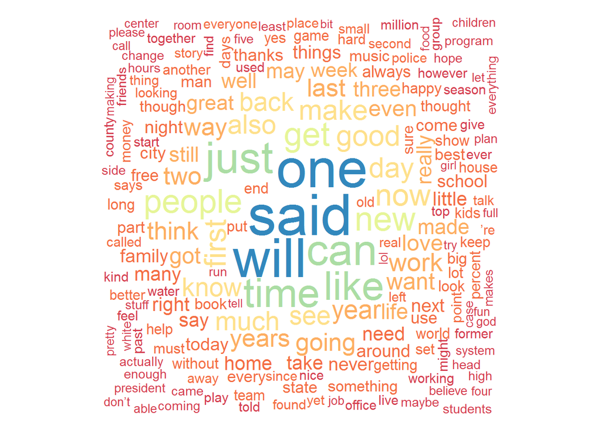

```r
# wordcloud {wordcloud} - plot a word cloud
wordcloud(corpus, min.freq = 25, random.order = FALSE, colors = brewer.pal(8, "Spectral"))
```

### N-Gram Plots

The following three plots illustrate the most common Unigrams, Bigrams, and Trigrams:

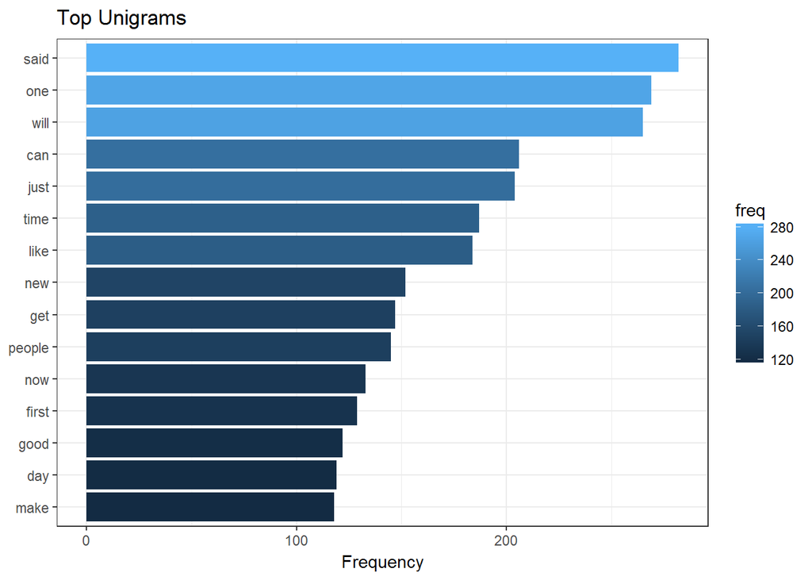

```r
plot_func <- function(freq,top,title) {
    freq_top <- head(freq,top)
    ggplot(freq_top,aes(x=reorder(word,freq), y=freq, fill=freq)) +
      geom_bar(stat = "identity") +
      theme_bw() +
      coord_flip() +
      theme(axis.title.y = element_blank()) +
      labs(y="Frequency", title=title)
}

plot_func(uniFreq,15,"Top Unigrams")
```

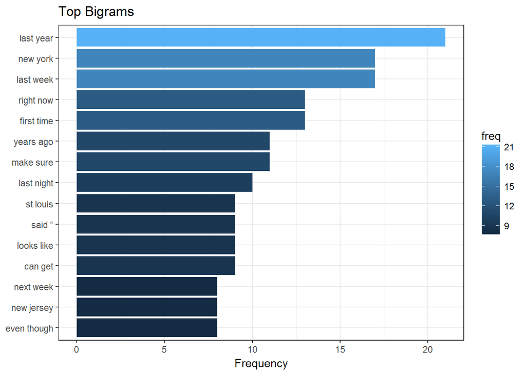

```r
plot_func(biFreq,15,"Top Bigrams")
```

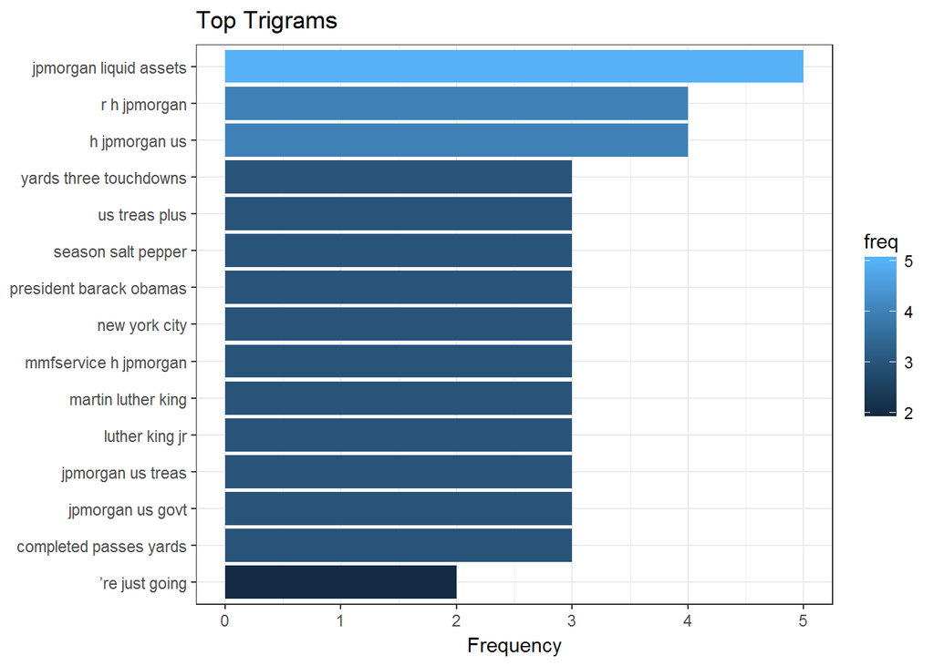

```r
plot_func(triFreq,15,"Top Trigrams")
```

## Conclusion

This milestone report covered importing, cleaning, and tokenizing the chosen text data sets, and accomplished some preliminary exploratory analysis with visualizations.

### Next Steps

The next steps planned for this capstone is to build the foundation of a Shiny prediction model application that allows a user to enter a word and be provided with the most likely next word. The tasks involved will include:

- Research NLP techniques and algorithms most useful for a predictive model.
- Build a basic n-gram model for predicting the next word based on the previous 1, 2, or 3 words.
- Build a model to handle unseen n-grams - cases where a particular n-gram hasn’t been observed in the source text.